# Publications

([return home](https://sirselim.github.io/))

#### A list of my peer-reviewed journal articles

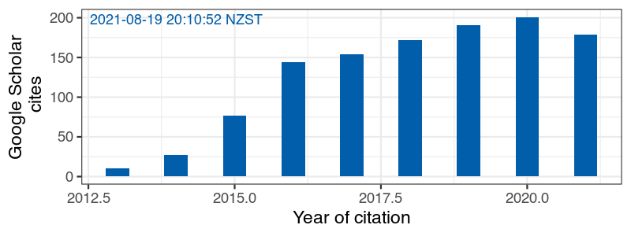

##### Publication Metrics

*(Where able I have provided a link to the full article.)*

## 2021

- Cao TV, Lea RA, Sutherland HG, **Benton MC**, Pishva SR, Haupt LM, and Griffiths LR. (2021) A genome-wide methylation study of body fat traits in the Norfolk Island Isolate. *Nutrition, Metabolism and Cardiovascular Diseases* (Accepted, awaiting publication)

## 2020

- Macartney-Coxson D, Cameron AM, Clapham J, and **Benton MC**. (2020) DNA methylation in blood-potential to provide new insights in immune cell biology. *PLOS ONE* 15(11): e0241367 [[article]](https://journals.plos.org/plosone/article?id=10.1371/journal.pone.0241367)
- Harvey NR, Voisin S, Lea RA, Yan X, **Benton MC**, Papadimitriou ID, Jacques M, Haupt LM, Ashton KJ, Eynon N, Griffiths and LR. Investigating the influence of mtDNA and nuclear encoded mitochondrial variants on high intensity interval training outcomes. (2020) *Scientific Reports* 10(1) [[article]](https://www.nature.com/articles/s41598-020-67870-1)
- Dunn PJ, Maher BH, Albury CL, Stuart S, Sutherland HG, Maksemous N, **Benton MC**, Smith, RA, Haupt LM, and Griffiths LR. (2020) Tiered analysis of whole-exome sequencing for epilepsy diagnosis. *Molecular Genetics and Genomics* (DOI:10.1007/s00438-020-01657-x)
- Harvey NR, Voisin S, Lea RA, Yan X, **Benton MC**, Papadimitriou ID, Jacques M, Haupt LM, Ashton KJ, Eynon N, Griffiths and LR. (2020) Identification of novel mitochondrial and mitochondrial related genetic loci associated with exercise response in the Gene SMART study. *biorxiv* (DOI: 10.1101/2020.02.20.957340)
- Macartney-Coxson D, Danielson K, Clapham J, **Benton MC**, Johnstone A, Jones A, Shaw O, Hagan RD, Hoffman EP, Hayes M, Harper J, Langston MA, and Stubbs RS. (2020) MicroRNA profiling in adipose before and after weight-loss highlights the role of miR-223-3p and the NLRP3 inflammasome. *Obesity* (epub 2020) (DOI:10.1002/oby.22722)
- Osborne AJ, Pearson JF, Noble AJ, Gemmell NJ, Horwood LJ, Boden JM, **Benton MC**, Macartney-Coxson D, and Kennedy MA. (2020) Genome-wide DNA methylation analysis of heavy cannabis exposure in a New Zealand longitudinal cohort. *Translational Psychiatry* 10(1) http://biorxiv.org/content/early/2019/11/07/829598.abstract

## 2019

- Harvey NR, Albury CL, Stuart S, **Benton MC**, Ecccles DA, Connell J, Sutherland HG, Allcock RJ, Lea RA, Haupt LM, and Griffiths LR. (2019) *Ion torrent high throughput mitochondrial genome sequencing (HTMGS)*. *PLoS ONE* 14(11):e0224847 (DOI: 10.1371/journal.pone.0224847)
- **Benton MC**, Lea RA, Macartney-Coxson D, Sutherland HG, White NM, Kennedy DW, Mengersen K, Haupt LM, and Griffiths LR. (2019) *Genome-wide allele-specific methylation is enriched at gene regulatory regions in a multi-generation pedigree from the Norfolk Island isolate.* Epigenetics and Chromatin 12(60) (DOI: 10.1186/s13072-019-0304-7)
- **Benton MC**, Smith RA, Haupt LM, Albury CL, Maksemous N, Lea RA, and Griffiths LR. (2019) *Variant Call Format (VCF)-Diagnostic Annotation and Reporting Tool (VCF-DART) A Customizable Analysis Pipeline for Identification of Clinically Relevant Genetic Variants in Next-Generation Sequencing Data.* Journal of Molecular Diagnostics (In Press, Journal Pre-proof, Available online 20 August 2019) [[article]](https://www.sciencedirect.com/science/article/abs/pii/S1525157819303538)
- Kennedy DW, White NM, **Benton MC**, Lea RL and Mengersen K. (2019) *Cell-type specific analysis of heterogeneous methylation signal using a Bayesian model-based approach.* biorxiv [[article]](https://www.biorxiv.org/content/10.1101/682070v1)

## 2018

- Kennedy D, White NM, **Benton MC**, Fox A, Scott R, Griffiths LR, Mengersen KL and Lea RA. (2018) *Critical evaluation of linear regression models for cell-subtype specific methylation signal from mixed blood cell DNA.* PLoS ONE Dec 20;13(12):e0208915 (DOI: 10.1371/journal.pone.0208915)
- MaltbyV, Lea RA, Graves M, Sanders K, **Benton MC**, Tajouri L, Scott R, and Lechner-Scott J. (2018) *Genome-wide DNA methylation changes in CD19+ B cells from relapsing-remitting multiple sclerosis patients.* Scientific Reports [[article]](https://www.nature.com/articles/s41598-018-35603-0)
- Aquino EM, **Benton MC**, Haupt LM, Sutherland HG, Griffiths LR, and Lea RA. (2018) *Current understanding of DNA methylation and age-related disease.* OBM Genetics 2(2) [[article]](http://www.lidsen.com/journals/genetics/genetics-02-02-016)
- Bradshaw G, Lualhati RL, Albury CL, Maksemous N, Roos-Araujo D, Smith RA, **Benton MC**, Eccles DA, Lea RA, Sutherland HG, Haupt LM and Griffiths LR. (2018) *Exome sequencing diagnoses X-linked moesin-associated immunodeficiency in a primary immunodeficiency case*. Frontiers in Immunology 9 [[article]](https://www.frontiersin.org/articles/10.3389/fimmu.2018.00420/abstract)
- Dunn P, Albury CL, Maksemous N, **Benton MC**, Sutherland HG, Smith RA, Haupt LM, and Griffiths LR. (2018) *Next Generation Sequencing Methods for Diagnosis of Epilepsy Syndromes.* Frontiers in Genetics (accepted 16th Janurary) 9 [doi: 10.3389/fgene.2018.00020] [[article]](https://www.frontiersin.org/articles/10.3389/fgene.2018.00020/full)
- Kho PF, Lea RA, **Benton MC**, Eccles DA, Haupt LM, Hewitt AW, Sherwin JC, Mackey DA, Griffiths LR. (2018) *Expression QTL analysis of glaucoma endophenotypes in the Norfolk Island isolate provides evidence that immune-related genes are associated with optic disc size.* Journal of Human Genetics **63** [doi: 10.1038/s10038-017-0374-y]

## 2017

- Matovinovic E, Kho PF, Lea RA, **Benton MC**, Eccles DA, Haupt LM, Hewitt AW, Sherwin JC, Mackey DA, and Griffiths LR. (2017) *Genome-wide linkage and association analysis of primary open-angle glaucoma endophenotypes in the Norfolk Island isolate.* Molecular Vision **23** [[article]](https://www.ncbi.nlm.nih.gov/pmc/articles/PMC5620381/)
- Jones A, Danielson KM, **Benton MC**, Ziegler O, Shah R, Stubbs RS, Das S, and Macartney-Coxson D. (2017) *miRNA signatures of insulin resistance in obesity.* Obesity 25(10) [doi: 10.1002/oby.21950]
- White NM, **Benton MC**, Kennedy D, Fox A, Griffiths LR, Lea RA, and Mengersen KL. (2017) *Accounting for cell lineage and sex effects in the identification of cell-specific DNA methylation using a Bayesian model selection algorithm.* PLoS One 12(9) [[article]](http://journals.plos.org/plosone/article?id=10.1371/journal.pone.0182455)
- Maltby V, Lea RA, Sanders K, White NM, **Benton MC**, Scott R, and Lechner-Scott J. (2017) *Differential Methylation at MHC in CD4+ T cells is associated with multiple sclerosis independently of HLA-DRB1.* Clinical Epigenetics 9(71) [[article]](https://clinicalepigeneticsjournal.biomedcentral.com/articles/10.1186/s13148-017-0371-1)
- Macartney-Coxson D, **Benton MC**, Blick R, Stubbs RS, Hagan RD, and Langston MA. (2017) *Genome-wide DNA methylation analysis reveals loci that distinguish different types of adipose tissue in obese individuals.* Clinical Epigenetics 9(48) [[article]](https://clinicalepigeneticsjournal.biomedcentral.com/articles/10.1186/s13148-017-0344-4)
- **Benton MC**, Sutherland HG, Macartney-Coxson D, Haupt LM, Lea RA, and Griffiths LR. (2017) *Methylome-wide association study of whole blood DNA in the Norfolk Island isolate identifies robust loci associated with age.* Aging 9(3) [[article]](http://www.aging-us.com/article/101187)
- Stuart S, **Benton MC**, Eccles D, Sutherland H, Haupt LM, Lea RA and Griffiths LR. (2017) *Gene-Centric Analysis Implicates Nuclear Encoded Mitochondrial Protein Gene Variants in Migraine Susceptibility.* Molecular Genetics & Genomic Medicine [[article]](http://onlinelibrary.wiley.com/doi/10.1002/mgg3.270/full)

## 2016

- Sanders KA, **Benton MC**, Lea RA, Maltby VE, Agland S, Griffin N, Scott RJ, Tajouri L and Lechner-Scott J. (2016) *Next-generation sequencing reveals broad down-regulation of microRNAs in secondary progressive multiple sclerosis CD4+ T-cells.* Clinical Epigenetics 8(87) [[article]](https://clinicalepigeneticsjournal.biomedcentral.com/articles/10.1186/s13148-016-0253-y)

## 2015

- Fernando S, Speicher DJ, Bakr MM, **Benton MC**, Lea RA, Scuffham PA and Johnson NW. (2015) *A Protocol for assessing maternal, environmental and epigenetic risk factors for dental caries in children.* BMC Oral Health 15(167) [[article]](http://www.ncbi.nlm.nih.gov/pmc/articles/PMC4696221/)
- **Benton MC**, Lea RA, Macartney-Coxson D, Carless MA, Bellis C, Hanna M, Eccles D, Chambers GK, Curran JE, Blangero J and Griffiths LR. (2015) *Serum bilirubin concentration is modified by UGT1A1 Haplotypes and Influences Risk of Type-2 Diabetes in the Norfolk Island Genetic Isolate.* BMC Genetics 16(1) [[article]](http://www.biomedcentral.com/1471-2156/16/136)
- Maltby VE, Graves MC, Lea RA, **Benton MC**, Sanders KA, Tajouri L, Scott RJ and Lechner-Scott J. (2015) *Genome-wide DNA methylation profiling of CD8+ T cells shows a distinct epigenetic signature to CD4+ T cells in Multiple Sclerosis patients.* Clinical Epigenetics 7(118) [[article]](http://www.clinicalepigeneticsjournal.com/content/7/1/118)
- **Benton MC**, Lea RA, Macartney-Coxson D, Carless MA, Göring HH, Bellis C, Hanna M, Eccles D, Chambers GK, Curran JE, Harper JL, Blangero J and Griffiths LR. (2015) *A phenomic scan of the Norfolk Island genetic isolate identifies a major pleiotropic effect locus associated with renal disorder markers.* PLoS Genetics 11(10) [[article]](http://journals.plos.org/plosgenetics/article?id=10.1371/journal.pgen.1005593)
- **Benton MC**, Stuart S, Bellis C, Macartney-Coxson D, Eccles D, Curran JE, Chambers G, Blangero J, Lea RA and Griffiths LR. (2015) *‘Mutiny on the Bounty’: The Genetic History of Norfolk Island reveals extreme gender biased admixture.* Investigative Genetics 6(11) [[article]](http://www.investigativegenetics.com/content/6/1/11)
- Rodriguez-Acevedo AJ, Ferreira MA, **Benton MC**, Carless MA, Göring HH, Curran JE, Blangero J, Lea RA and Griffiths LR. (2015) *Common Polygenic Variation Contributes to Risk of Migraine in the Norfolk Island Population.* Human Genetics (published online July 29th)
- Bosch P, **Benton MC**, Macartney-Coxson D and Kivell B. (2015) *mRNA and microRNA analysis reveals modulation of biochemical pathways related to addiction in the ventral tegmental area of methamphetamine self-administering rats.* BMC Neuroscience 16(1) [[article]](http://www.biomedcentral.com/1471-2202/16/43)
- Joshi PK, … **Benton MC**, Lea RA, Griffiths LR, … and Wislon JF. (2015) *Directional dominance on stature and cognition in diverse human populations.* Nature 523(7561) [[article]](https://www.ncbi.nlm.nih.gov/pmc/articles/PMC4516141/)
- **Benton MC**, Johnstone A, Eccles D, Harmon B, Hayes MT, Lea RA, Griffiths LR, Hoffman E, Stubbs RS and Macartney-Coxson D. (2015) *An analysis of DNA methylation in human adipose tissue reveals differential modification of obesity genes before and after gastric bypass and weight-loss.* Genome Biology 16(1) [[article]](http://genomebiology.com/2015/16/1/8)

## 2014

- Aya-Bonilla C, Camilleri E, **Benton MC**, Haupt LM, Marlton P, Lea RA, Gandhi MK and Griffiths LR. (2014) *Fine mapping of the 15q21 region implicate TP53BP1 and B2M in the lymphomagenesis of Follicular and Diffuse Large B-Cell lymphomas.* Carcinogenesis & Mutagenesis 5(6) [[article]](http://www.omicsonline.org/open-access/fine-mapping-of-the-q-region-implicates-tpbp-and-bm-in-the-lymphomagenesis-of-follicular-and-diffuse-large-bcell-lymphomas-2157-2518-5-195.php?aid=35416)
- Gunawardhana LP, Gibson PG, Simpson JL, **Benton MC**, Lea RA and Baines, KJ. (2014) *Characteristic DNA methylation profiles in peripheral blood monocytes are associated with inflammatory phenotypes of asthma.* Epigenetics 9(9) [[article]](http://www.ncbi.nlm.nih.gov/pmc/articles/PMC4169022/)

## 2013

- **Benton MC**, Lea RA, Macartney-Coxson D, Carless MA, Göring HH, Bellis C, Hanna M, Eccles D, Chambers GK, Curran JE, Harper JL, Blangero J and Griffiths LR. (2013) *Mapping eQTLs in the Norfolk Island Genetic Isolate Identifies Candidate Genes for CVD-risk Traits.* American Journal of Human Genetics 93(6): 1087-99 [[article]](http://www.ncbi.nlm.nih.gov/pmc/articles/PMC3853002/)
- Graves M, **Benton MC**, Lea R, Boyle M, Tajouri L, Macartney-Coxson D, Scott R and Lechner-Scott J. (2013) *Methylation differences at the HLA-DRB1 locus in CD4+ T-Cells are associated with multiple sclerosis.* Multiple Sclerosis 20(8):1033-1041
- Aya-Bonilla C, Green MR, Camilleri E, **Benton MC**, Keane C, Marlton P, Lea RA, Gandhi MK and Griffiths LR. (2013) *High resolution loss of heterozygosity screening implicates PTPRJ as a potential tumor suppressor gene that affects susceptibility to non-Hodgkin’s lymphoma.* Genes, Chromosomes and Cancer 52(5):467-79
- Rodriguez-Acevedo AJ, Maher BH, Lea RA, **Benton MC** and Griffiths LR. (2013) *Association of oestrogen-receptor gene (ESR1) polymorphisms with migraine in the large Norfolk Island pedigree.* Cephalalgia 33(14):1139-1147
- Stuart S, Maher BH, Sutherland H, **Benton MC**, Rodriguez A, Lea RA, Haupt LM and Griffiths LR. (2013) *Genetic Variation in Cytokine-Related Genes and Migraine Susceptibility.* Twin Res Hum Genet 20:1-8 [[article]](http://journals.cambridge.org/action/displayFulltext?type=6&fid=9081381&jid=THG&volumeId=16&issueId=06&aid=9081380&bodyId=&membershipNumber=&societyETOCSession=&fulltextType=RA&fileId=S1832427413000637)

## 2012

- **Benton MC**, Macartney-Coxson D, Eccles DA, Griffiths LR, Chambers GK and Lea, RA. (2012) *Complete Mitochondrial Genome Sequencing Reveals Novel Haplotypes in a Polynesian Population.* PLoS ONE 7(4): e35026 [[article]](http://journals.plos.org/plosone/article?id=10.1371/journal.pone.0035026)
- Maher BH, Lea RA, **Benton MC**, Cox HC, Bellis C, Carless M, Dyer TD, Curran J, Charlesworth JC, Buring JE, Kurth T, Chasman DI, Ridker PM, Schürks M, Blangero J and Griffiths LR. (2012) *An X Chromosome Association Scan of the Norfolk Island Genetic Isolate Provides Evidence for a Novel Migraine Susceptibility Locus at Xq12.* PLoS ONE 7(5): e37903 [[article]](http://journals.plos.org/plosone/article?id=10.1371/journal.pone.0037903)